# Chris Humphrey

## Visualizing and Mapping Restaurants in Portland

Portland is a great city that I was fortunate to spend some time in this Summer. It's a city with an interesting vibe, and equally interesting restaurants. I came across a dataset provided by Yelp, and thought combing through the data would make for a fun project in data visualization. The dataset is a JSON file which contains (assumingly) all restaurants in Portland, along with attributes such as which cuisine they serve, and their GPS coordinates.

I will be making two visualizations. After cleaning the data, I will make a violin plot showing the distribution of Yelp reviews in Portland, aggregated by cuisine type (Italien, American, Japanese, ...). Second, I will make a heatmap of the locations of restaurants scaled by the average rating of said restaurants.

```python
import json
import numpy as np
from numpy.lib.index_tricks import AxisConcatenator


class Restaurants:

    headers = [
        "Name",
        "Location",
        "Stars",
        "Review Count",
        "Dogs Allowed",
        "Bike Parking",
    ]

    cuisines = [
        "American",
        "Burgers",
        "Fast Food",
        "Coffee",
        "Bars",
        "Nightlife",
        "Breweries",
        "Italian",
        "Chinese",
        "Asian Fusion",
        "Korean",
        "Japanese",
        "Sushi",
        "Thai",
        "Pizza",
        "Soup",
        "Salad",
        "Delis",
        "Food Truck",
        "Street",
        "Seafood",
        "Veg",
        "Indian",
        "Ice Cream",
        "Tacos",
        "Mexican",
        "Bakeries",
        "Sandwiches",
    ]

    final_array = np.concatenate((headers, cuisines), axis=None)

    def __init__(self, data):
        self.name = data["name"]
        self.location = [data["latitude"], data["longitude"]]  # DEPRECATION WARNING
        self.stars = data["stars"]
        self.review_count = data["review_count"]
        self.dogs_allowed = 0
        self.bike_parking = 0
        self.temp_array = np.zeros(6, dtype=int)
        self.temp_cuisines = np.zeros(len(Restaurants.cuisines), dtype=int)

        if data["attributes"]:
            if "DogsAllowed" in data["attributes"]:
                if data["attributes"]["DogsAllowed"] == "True":
                    self.dogs_allowed = 1
            if "BikeParking" in data["attributes"]:
                if data["attributes"]["BikeParking"] == "True":
                    self.bike_parking = 1

        for i in range(len(Restaurants.cuisines)):
            if Restaurants.cuisines[i] in data["categories"]:
                self.temp_cuisines[i] = 1

        self.temp_array = np.array(
            [
                self.name,
                self.location,
                self.stars,
                self.review_count,
                self.dogs_allowed,
                self.bike_parking,
            ]
        )
        new_row = np.concatenate((self.temp_array, self.temp_cuisines), axis=None)

        Restaurants.final_array = np.vstack((Restaurants.final_array, new_row))


def main():

    with open("yelp_academic_dataset_business.json") as f:
        for line in f:
            data = json.loads(line)

            if (
                data["city"] == "Portland"
                and data["is_open"] == 1
                and data["categories"]
            ):

                if (
                    "Restaurants" in data["categories"]
                    or "Restaurant" in data["categories"]
                    or "restaurants" in data["categories"]
                    or "restaurant" in data["categories"]
                ):
                    x = Restaurants(data)

        np.savetxt("foo.csv", Restaurants.final_array, delimiter=",", fmt="%s")


main()
```

```python
import pandas as pd
import numpy as np
import seaborn as sns
import geopandas as gpd
import pandas as pd
import folium
from folium.plugins import HeatMap

df = pd.read_csv("cleaned_table_2.csv", header=1)

# Clean the GPS coordinate data; removing characters
for index, row in df.iterrows():
    df.loc[index, "Latitude"] = row["Latitude"].replace("[", "")

for index, row in df.iterrows():
    df.loc[index, "Longitude"] = row["Longitude"].replace("]", "")
```

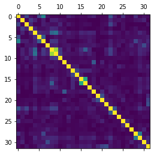

```python
import matplotlib.pyplot as plt

# See which columns are highly correlated/redundant.
# Will combine and remove redundant columns

corr_matrix = df.corr().abs()
plt.matshow(df.corr().abs())
plt.show()

# Deprecation Warning
sol = (
    corr_matrix.where(np.triu(np.ones(corr_matrix.shape), k=1).astype(np.bool))
    .stack()
    .sort_values(ascending=False)
)
```

```python
for index, value in sol.items():
    print(index, value)

#  We see that Bars+Nightlife , Japanese + Sushi, Tacos + Mexican correlate and are redundant
# Let's combine those colum pairs, and drop redundant columns

for index, row in df.iterrows():
    if row["Bars"] == 1 or row["Nightlife"] == 1:
        df.loc[index, "Bars"] = 1
df = df.drop(["Nightlife"], axis=1)

for index, row in df.iterrows():
    if row["Japanese"] == 1 or row["Sushi"] == 1:
        df.loc[index, "Japanese"] = 1
df = df.drop(["Sushi"], axis=1)

for index, row in df.iterrows():
    if row["Mexican"] == 1 or row["Tacos"] == 1:
        df.loc[index, "Mexican"] = 1
df = df.drop(["Tacos"], axis=1)

for index, row in df.iterrows():
    if row["Food Truck"] == 1 or row["Street"] == 1:
        df.loc[index, "Street"] = 1
df = df.drop(["Food Truck"], axis=1)
```

```
('Bars', 'Nightlife') 0.8488083494661861
('Japanese', 'Sushi') 0.6031089444282572
('Stars', 'Fast Food') 0.45143855806153915
('Tacos', 'Mexican') 0.40323978565112895
('American', 'Nightlife') 0.3784129432665705
('American', 'Bars') 0.32368537085728494
('Bars', 'Sushi') 0.29245120557515464
('Burgers', 'Fast Food') 0.2884957990586375
('Italian', 'Pizza') 0.28033449984047987
```

```python
df2 = df.select_dtypes(include="int")
df2 = df2.drop(["Review Count", "Dogs Allowed", "Bike Parking"], axis=1)
df2 = df2.join(df["Stars"])

true_columns = []


# Parsing and recasting data in a new dataframe to match format for the Seaborn plot
for index, row in df2.iterrows():
    for col in df2:
        if row[col] == 1:
            true_columns += [col, row[-1]]

true_columns = np.asarray(true_columns)
true_columns = true_columns.reshape(-1, 2)
df3 = pd.DataFrame(true_columns, columns=["Cuisine", "Stars"])

# Readding "stars", which is the y-axis in the Seaborn plot
df3["Stars"] = df["Stars"].astype(float)
df3 = df3[df3["Cuisine"] != "Stars"]
```

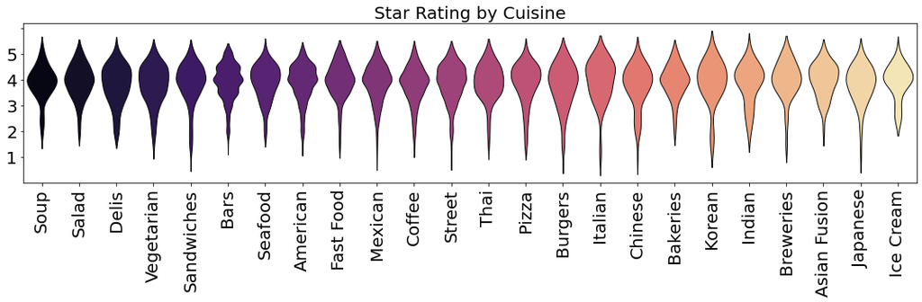

```python
plt.figure(figsize=(15, 5))
violins = sns.violinplot(
    data=df3,
    y="Stars",
    x="Cuisine",
    inner=None,
    linewidth=1,
    scale="width",
    palette="magma",
)

violins.set_title("Star Rating by Cuisine", fontsize=20)
violins.set_ylabel("")
violins.set_xlabel("")
violins.set_yticklabels(["", "1", "2", "3", "4", "5"], fontsize=20)
plt.xticks(rotation=90, fontsize=20)

plt.tight_layout()
plt.savefig("ratings_chart.png", dpi=300)
```

```python
hmap = folium.Map(
    location=[45.5253094, -122.677018],
    zoom_start=13,
)

hm_wide = HeatMap(
    list(zip(df.Latitude.values, df.Longitude.values, df.Stars.values)),
    min_opacity=0.3,
    radius=12,
    blur=12,
    max_zoom=1,
)

hmap.add_child(hm_wide)
```

[figure not shown]

My experience: Working at a digital marketing consultancy meant that I helped many companies run A/B tests. I assisted marketers with forming better testing protocols. I saw where some companies had trouble, and where others flourished. Here are 6 lessons I learned.

**The goal is to learn about your customer, not just to lift conversion.**

The goal of A/B testing is to learn about your customer. With that mindset, all A/B tests, even the failed ones, present a learning opportunity.

After observing a particular facet of customer behavior, ask yourself: what could this behavior reveal about my customer? Maybe customers are making the effort to navigate themselves to a page on the warranty. This could give insight to how important the warranty is to a segment of your customer base.

Next, form a hypothesis. The hypothesis should be formatted in this way:

If we [do this] then customers may [do this] because [of this reason].

Going back to the warranty example, our hypothesis could be the following:

If we highlight warranty value on the landing page customers may increase their clickthrough because the warranty is important to them.

After running an A/B test on the hypothesis, you may or may not see a change in the conversion rate. Even a “failed” test is still a success, in that we learned more about our customer. The best A/B testing approach is one where you experiment to learn about your customer, instead of just trying to increase conversion. With this approach, all A/B tests should provide inspiration for future A/B tests.

**Design Your A/B Tests in Series**

If you approach testing with the mindset to learn about customer psychology, then you should be designing your tests in series. Every test provides a learning opportunity, and that learning opportunity gives insight on what to test next.

**Q/A for flickers.**

You’d be surprised by how many tests I saw companies run that had to be thrown out because of bunk data. Testing platforms are rife with glitches, and the most dangerous A/B tests are those with glitches that go unnoticed.

A common and often unnoticed glitch is the “flicker.” It is more likely to happen on overlay tests. The “flicker” is where a cookie misfires and counts an individual as being in both the A and B experiences, or neither.

You’ll want to QA your test on different browsers and devices. After the test is launched bring up the testing platform and website side-by-side. Click around the website and watch the testing platform track you in real time to ensure that data is being collected properly.

**Know when to end the test**

Many websites do not have enough traffic to A/B test for minor conversion rate lifts at significance. You may never reach conversion, but eventually you’ll have to end the test. Instead of looking at the primary KPI, comb through the data to see if there are any other trends in how customer behavior changed. This insight can be just as valuable as the original A/B test.

**Target the correct KPI**

If a website does not have enough traffic to test final conversion or purchase, then try to find a proxy KPI. This may be clickthrough from the landing page.

However, there are dangers in doing this. I once worked with a company that used clickthrough as their proxy KPI, and designed all A/B tests around increasing clickthrough rate. The result was a website where many people clicked through 7 pages, until they came to the final purchase page, and exited the website. The website had a high clickthrough rate, but low conversion rate.

Your proxy KPI should be something that correlates well with the conversion rate.

## Visualizing and Mapping Restaurants in Portland

Portland is a great city that I was fortunate to spend some time in this Summer. It's a city with an interesting vibe, and equally interesting restaurants. I came across a dataset provided by Yelp, and thought combing through the data would make for a fun project in data visualization. The dataset is a JSON file which contains (assumingly) all restaurants in Portland, along with attributes such as which cuisine they serve, and their GPS coordinates.

I will be making two visualizations. After cleaning the data, I will make a violin plot showing the distribution of Yelp reviews in Portland, aggregated by cuisine type (Italien, American, Japanese, ...). Second, I will make a heatmap of the locations of restaurants scaled by the average rating of said restaurants.

```python
import json
import numpy as np
from numpy.lib.index_tricks import AxisConcatenator


class Restaurants:

    headers = [
        "Name",
        "Location",
        "Stars",
        "Review Count",
        "Dogs Allowed",
        "Bike Parking",
    ]

    cuisines = [
        "American",
        "Burgers",
        "Fast Food",
        "Coffee",
        "Bars",
        "Nightlife",
        "Breweries",
        "Italian",
        "Chinese",
        "Asian Fusion",
        "Korean",
        "Japanese",
        "Sushi",
        "Thai",
        "Pizza",
        "Soup",
        "Salad",
        "Delis",
        "Food Truck",
        "Street",
        "Seafood",
        "Veg",
        "Indian",
        "Ice Cream",
        "Tacos",
        "Mexican",
        "Bakeries",
        "Sandwiches",
    ]

    final_array = np.concatenate((headers, cuisines), axis=None)

    def __init__(self, data):
        self.name = data["name"]
        self.location = [data["latitude"], data["longitude"]]  # DEPRECATION WARNING
        self.stars = data["stars"]
        self.review_count = data["review_count"]
        self.dogs_allowed = 0
        self.bike_parking = 0
        self.temp_array = np.zeros(6, dtype=int)
        self.temp_cuisines = np.zeros(len(Restaurants.cuisines), dtype=int)

        if data["attributes"]:
            if "DogsAllowed" in data["attributes"]:
                if data["attributes"]["DogsAllowed"] == "True":
                    self.dogs_allowed = 1
            if "BikeParking" in data["attributes"]:
                if data["attributes"]["BikeParking"] == "True":
                    self.bike_parking = 1

        for i in range(len(Restaurants.cuisines)):
            if Restaurants.cuisines[i] in data["categories"]:
                self.temp_cuisines[i] = 1

        self.temp_array = np.array(
            [
                self.name,
                self.location,
                self.stars,
                self.review_count,
                self.dogs_allowed,
                self.bike_parking,
            ]
        )
        new_row = np.concatenate((self.temp_array, self.temp_cuisines), axis=None)

        Restaurants.final_array = np.vstack((Restaurants.final_array, new_row))


def main():

    with open("yelp_academic_dataset_business.json") as f:
        for line in f:
            data = json.loads(line)

            if (
                data["city"] == "Portland"
                and data["is_open"] == 1
                and data["categories"]
            ):

                if (
                    "Restaurants" in data["categories"]
                    or "Restaurant" in data["categories"]
                    or "restaurants" in data["categories"]
                    or "restaurant" in data["categories"]
                ):
                    x = Restaurants(data)

        np.savetxt("foo.csv", Restaurants.final_array, delimiter=",", fmt="%s")


main()
```

```python
import pandas as pd
import numpy as np
import seaborn as sns
import geopandas as gpd
import pandas as pd
import folium
from folium.plugins import HeatMap

df = pd.read_csv("cleaned_table_2.csv", header=1)

# Clean the GPS coordinate data; removing characters
for index, row in df.iterrows():
    df.loc[index, "Latitude"] = row["Latitude"].replace("[", "")

for index, row in df.iterrows():
    df.loc[index, "Longitude"] = row["Longitude"].replace("]", "")
```

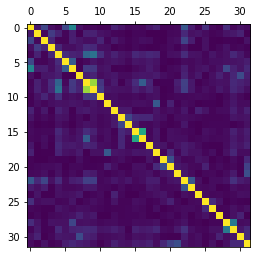

```python
import matplotlib.pyplot as plt

# See which columns are highly correlated/redundant.
# Will combine and remove redundant columns

corr_matrix = df.corr().abs()
plt.matshow(df.corr().abs())
plt.show()

# Deprecation Warning
sol = (
    corr_matrix.where(np.triu(np.ones(corr_matrix.shape), k=1).astype(np.bool))
    .stack()
    .sort_values(ascending=False)
)
```

```python
for index, value in sol.items():
    print(index, value)

#  We see that Bars+Nightlife , Japanese + Sushi, Tacos + Mexican correlate and are redundant
# Let's combine those colum pairs, and drop redundant columns

for index, row in df.iterrows():
    if row["Bars"] == 1 or row["Nightlife"] == 1:
        df.loc[index, "Bars"] = 1
df = df.drop(["Nightlife"], axis=1)

for index, row in df.iterrows():
    if row["Japanese"] == 1 or row["Sushi"] == 1:
        df.loc[index, "Japanese"] = 1
df = df.drop(["Sushi"], axis=1)

for index, row in df.iterrows():
    if row["Mexican"] == 1 or row["Tacos"] == 1:
        df.loc[index, "Mexican"] = 1
df = df.drop(["Tacos"], axis=1)

for index, row in df.iterrows():
    if row["Food Truck"] == 1 or row["Street"] == 1:
        df.loc[index, "Street"] = 1
df = df.drop(["Food Truck"], axis=1)
```

```
('Bars', 'Nightlife') 0.8488083494661861
('Japanese', 'Sushi') 0.6031089444282572
('Stars', 'Fast Food') 0.45143855806153915
('Tacos', 'Mexican') 0.40323978565112895
('American', 'Nightlife') 0.3784129432665705
('American', 'Bars') 0.32368537085728494
('Bars', 'Sushi') 0.29245120557515464
('Burgers', 'Fast Food') 0.2884957990586375
('Italian', 'Pizza') 0.28033449984047987
```

```python
df2 = df.select_dtypes(include="int")
df2 = df2.drop(["Review Count", "Dogs Allowed", "Bike Parking"], axis=1)
df2 = df2.join(df["Stars"])

true_columns = []


# Parsing and recasting data in a new dataframe to match format for the Seaborn plot
for index, row in df2.iterrows():
    for col in df2:
        if row[col] == 1:
            true_columns += [col, row[-1]]

true_columns = np.asarray(true_columns)
true_columns = true_columns.reshape(-1, 2)
df3 = pd.DataFrame(true_columns, columns=["Cuisine", "Stars"])

# Readding "stars", which is the y-axis in the Seaborn plot
df3["Stars"] = df["Stars"].astype(float)
df3 = df3[df3["Cuisine"] != "Stars"]
```

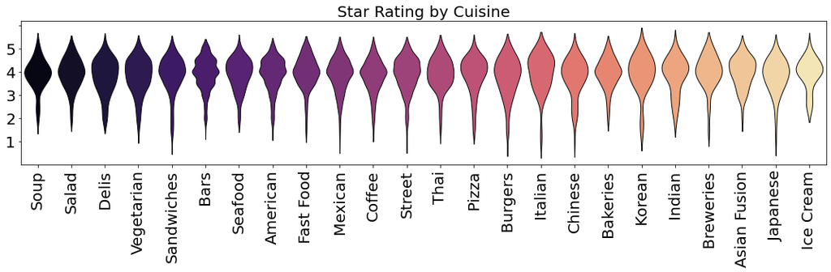

```python
plt.figure(figsize=(15, 5))
violins = sns.violinplot(
    data=df3,
    y="Stars",
    x="Cuisine",
    inner=None,
    linewidth=1,
    scale="width",
    palette="magma",
)

violins.set_title("Star Rating by Cuisine", fontsize=20)
violins.set_ylabel("")
violins.set_xlabel("")
violins.set_yticklabels(["", "1", "2", "3", "4", "5"], fontsize=20)
plt.xticks(rotation=90, fontsize=20)

plt.tight_layout()
plt.savefig("ratings_chart.png", dpi=300)
```

```python
hmap = folium.Map(
    location=[45.5253094, -122.677018],
    zoom_start=13,
)

hm_wide = HeatMap(
    list(zip(df.Latitude.values, df.Longitude.values, df.Stars.values)),
    min_opacity=0.3,
    radius=12,
    blur=12,
    max_zoom=1,
)

hmap.add_child(hm_wide)
```

[figure not shown]